# 2015-2018 MLB Pitch Data

## by Andrew Schutte

## Investigation Overview

> I want to visualize the pitches throw by MLB pitcher, Zack Greinke. This includes the pitch speeds, pitch location and the results of each pitch/atbat.

## Dataset Overview

> This dataset was scrapped from MLB Gameday data. I got the dataset from [Kaggle](https://www.kaggle.com/pschale/mlb-pitch-data-20152018). This provides a lot of data and information on each pitch. For more information, read this [link.](https://fastballs.wordpress.com/2007/08/02/glossary-of-the-gameday-pitch-fields/)

## Histogram of Pitch Start Speeds

> This shows the frequency of the start speed for all of Greinke's pitches. This distribution is affected by the fact that Greinke throws 6 different pitches. These 6 different pitches vary his overall start speeds. We do see a spike in frequency around 90 MPH. There's a good chance that the most common pitch he throws starts with a speed around 90.

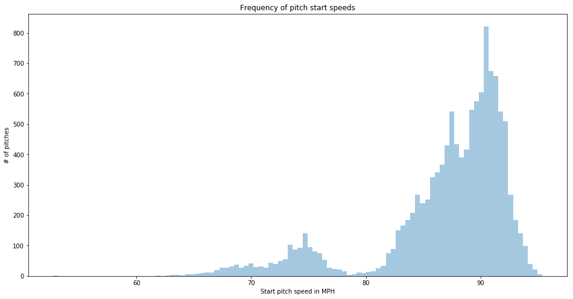

```python
plt.figure(figsize= (16,8))
sb.distplot(df.start_speed, bins = 100,  kde=False);
plt.ylabel('# of pitches');
plt.xlabel('Start pitch speed in MPH');
plt.title('Frequency of pitch start speeds');
```

## Histogram of Pitch End Speeds

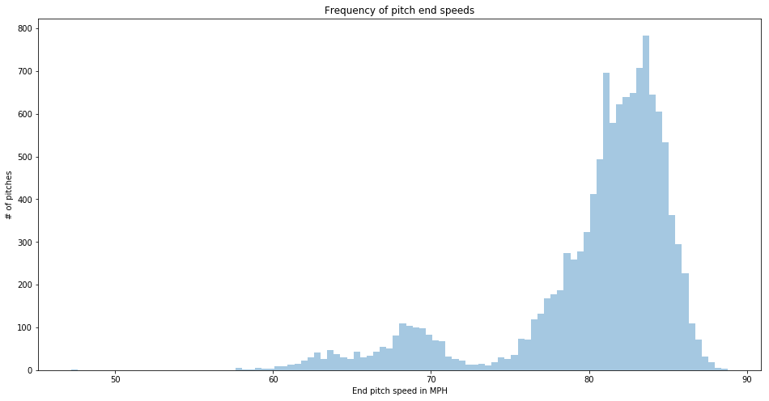

```python
plt.figure(figsize= (16,8))
sb.distplot(df.end_speed, bins = 100,  kde=False);
plt.ylabel('# of pitches');
plt.xlabel('End pitch speed in MPH');
plt.title('Frequency of pitch end speeds');
```

## Frequency of Pitch Types

> The histograms are such an odd distribution because each pitch has a different start and end speed range. Lets see what type of pitches Greinke throws. Notice that the four seam fastball is the most common. Back in our histograms, we saw that his most common pitch was around 85-90. We can now assume that is the four seam fastball.

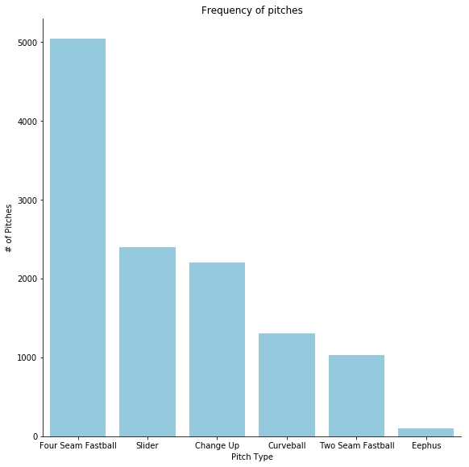

```python
g = sb.catplot(data = df, x = 'pitch_type', kind = 'count', order = df.pitch_type.value_counts().index, color = 'skyblue', height = 8, aspect = 1);
g.set_xticklabels(['Four Seam Fastball', 'Slider', 'Change Up', 'Curveball', 'Two Seam Fastball', 'Eephus'])
plt.xlabel('Pitch Type');
plt.ylabel('# of Pitches');
plt.title('Frequency of pitches');
```

## Start and End Speeds by Pitch Type

> The histograms had a big spread and an odd distribution. Pitch type is really important. Each pitch type has it's own range. We assumed that our four seam fastball was that pitch that gave us such a big leap in the frequency around 90 MPH. We also see the two seam fastball. That pitch isn't as common, but we see the start speed and end speed is roughly the same as his four seam. The two seam is also supposed to move more than a four seam. It is also important to notice the start and end speeds of the other pitches. Greinke has a good speed difference across each of his unique pitch types.

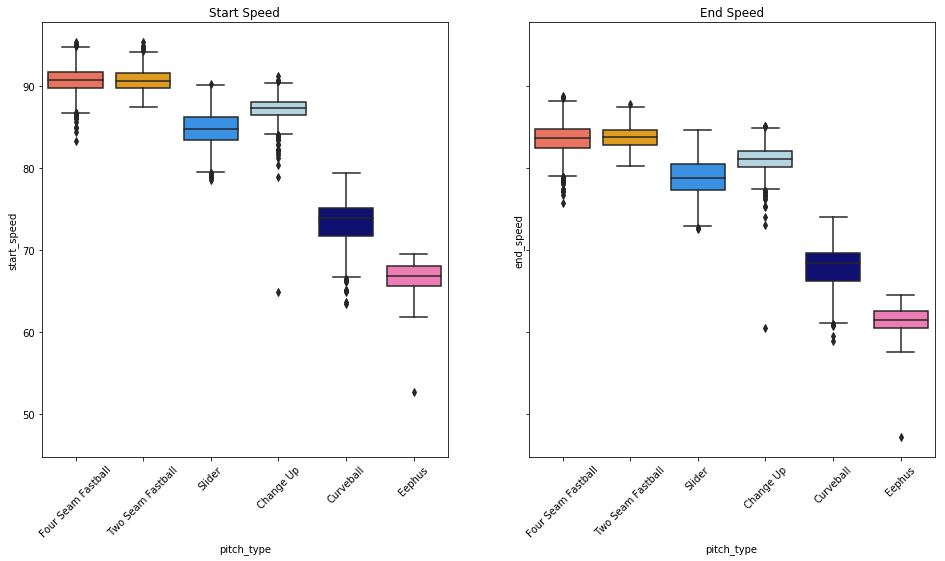

```python
fig, ax = plt.subplots(1,2, figsize = [16,8], sharey='row')
ax = ax.flatten()

ax1 = sb.boxplot(data = df, x = 'pitch_type', y = 'start_speed', palette = ['tomato', 'orange','dodgerblue','lightblue','navy', 'hotpink'], ax=ax[0])
ax2 = sb.boxplot(data = df, x = 'pitch_type', y = 'end_speed',  palette = ['tomato', 'orange','dodgerblue','lightblue','navy', 'hotpink'], ax=ax[1])
ax1.set_xticklabels(['Four Seam Fastball', 'Two Seam Fastball', 'Slider', 'Change Up', 'Curveball', 'Eephus'], rotation = 45)
ax2.set_xticklabels(['Four Seam Fastball', 'Two Seam Fastball','Slider', 'Change Up', 'Curveball',  'Eephus'], rotation = 45)
ax1.title.set_text('Start Speed')
ax2.title.set_text('End Speed')
```

## Pitch Result with Pitch Type

> The dataset has a code for each pitch's individual result. We should look at the percentage pitch type usage for each pitch result. One interesting insight is that Greinke uses his slider to get swings and misses low, but the pitch is also a ball in the dirt often. Greinke also gets a lot of called strikes with his fastball, and a lot of swinging strikes with his slider. He throws these the pitches the most and they are highly effective.

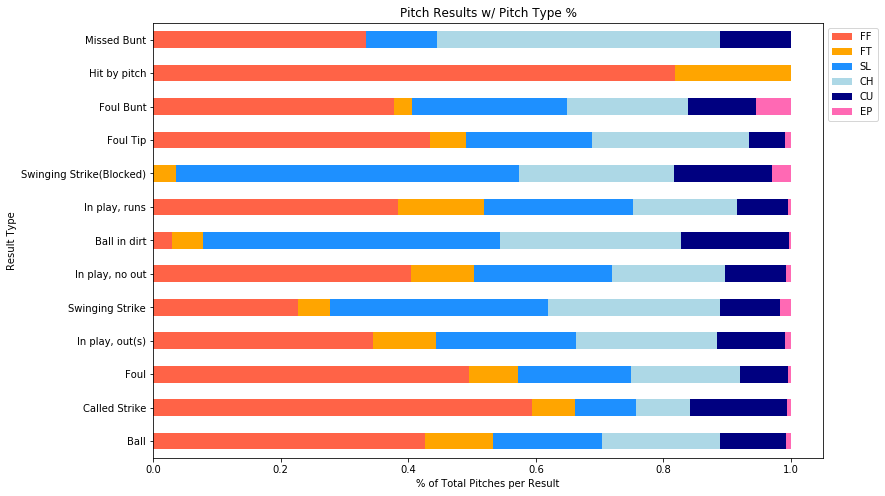

```python
p_table = pd.pivot_table(df,index='code',columns='pitch_type',aggfunc='size')
p_table = p_table.div(p_table.sum(axis=1), axis=0)
ax = p_table.plot.barh(stacked=True, figsize=(12,8), color = ['tomato', 'orange','dodgerblue','lightblue','navy', 'hotpink'])
ax.legend(bbox_to_anchor=(1,1));
plt.title('Pitch Results w/ Pitch Type %');
plt.ylabel('Result Type');
plt.xlabel('% of Total Pitches per Result');
```

## At Bat Results with Pitch Type

> Let's look at the at bat results with pitch types. We can draw conclusions about which pitches work for Greinke. Greinke uses his slider for a lot of strike outs. This builds off our last visual where we saw Greinke gets a lot of swing and misses on his slider. It is also good to note that he has more strike outs than any other atbat result. This is impressive, but he can also get outs many other ways. If we were to combine fly out and ground out, that would be a higher total than his strikeouts. Nonetheless, Greinke is still impressive.

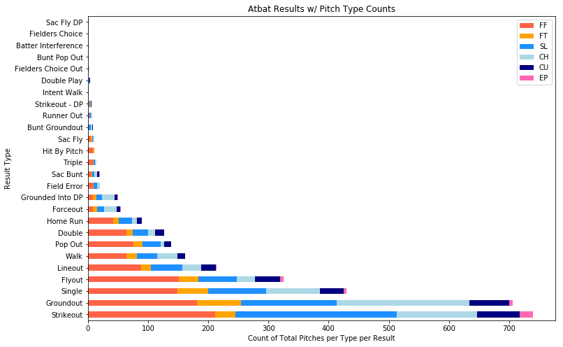

```python
eve = dfEvent.event.value_counts().index
code = df.code.value_counts().index
pi_type = CategoricalDtype(categories=["FF","FT","SL" ,"CH", "CU", "EP"],ordered=True)
ev_type = CategoricalDtype(categories=eve, ordered=True)
co_type = CategoricalDtype(categories=code, ordered=True)
dfEvent.pitch_type = dfEvent.pitch_type.astype(pi_type)
df.pitch_type = df.pitch_type.astype(pi_type)
dfEvent.event = dfEvent.event.astype(ev_type)
df.code = df.code.astype(co_type)
c = pd.crosstab(dfEvent['event'], dfEvent['pitch_type'])
#c.sort_values(by = dfEvent.event,ascending=False)
ax = c.plot.barh(stacked=True,  figsize=(12,8),color = ['tomato', 'orange','dodgerblue','lightblue','navy', 'hotpink'])
ax.legend(bbox_to_anchor=(1,1));
plt.title('Atbat Results w/ Pitch Type Counts');
plt.ylabel('Result Type');
plt.xlabel('Count of Total Pitches per Type per Result');
plt.show()
```

## Four Seam Fastball Location Heat Map

> This is interesting to see where Greinke throws his fastball. He throws it a lot on the right side of the plate. (View from the catcher). The black square is the average strike zone. Anything inside of the box is usually a strike. Human error is often prevalent in baseball.

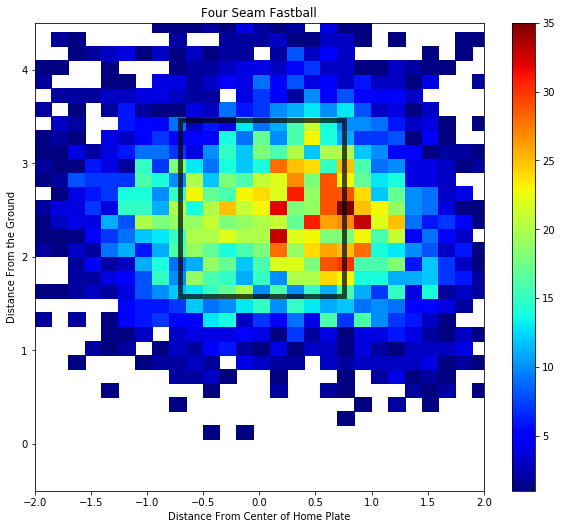

```python
left, width = 0.1, 0.65
bottom, height = 0.1, 0.65
bottom_h = left_h = left + width + 0.02

rect_scatter = [left, bottom, width, height]
#rect_histx = [left, bottom_h, width, 0.2]
#rect_histy = [left_h, bottom, 0.2, height]

plt.figure(1, figsize=(12, 10))

# start with a rectangular Figure

axScatter = plt.axes(rect_scatter)
#axHistx = plt.axes(rect_histx)
#axHisty = plt.axes(rect_histy)
bins_x = np.arange(-2, 0.1+2,0.15)
bins_y = np.arange(-1, 0.1+6, 0.15)
plt.hist2d(data = ff, x = 'px', y = 'pz', bins = [bins_x, bins_y], cmap = 'jet', cmin = 1);
axScatter.set_xlim((-2, 2))
axScatter.set_ylim((-0.5, 4.5))
someX = 0
someY = 3.4632659
axScatter.add_patch(Rectangle((someX - .7083 , someY - 1.8832 ), 1.467, 1.8832, color = 'black',fill=None, alpha=0.7, lw = 5))
plt.colorbar();
plt.title('Four Seam Fastball');
plt.xlabel('Distance From Center of Home Plate')
plt.ylabel('Distance From the Ground');
```

## Two Seam Fastball Location Heat Map

> This is interesting to see where Greinke throws his two seam fastball. He throws it a lot in the lower left corner of the strike zone. (View from the catcher). This pitch moves from right to left for Greinke. This movement makes the best location for this pitch in that lower left corner. It can look like it starts in the strike zone but then moves out of the zone.

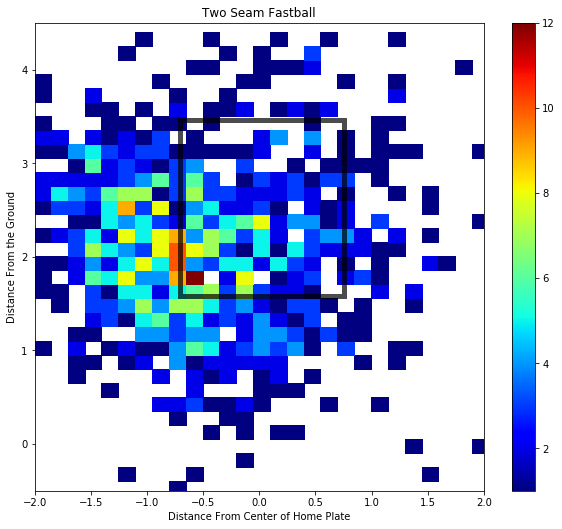

```python
left, width = 0.1, 0.65
bottom, height = 0.1, 0.65
bottom_h = left_h = left + width + 0.02

rect_scatter = [left, bottom, width, height]
#rect_histx = [left, bottom_h, width, 0.2]
#rect_histy = [left_h, bottom, 0.2, height]

plt.figure(1, figsize=(12, 10))

# start with a rectangular Figure


axScatter = plt.axes(rect_scatter)
#axHistx = plt.axes(rect_histx)
#axHisty = plt.axes(rect_histy)
bins_x = np.arange(-2, 0.1+2,0.15)
bins_y = np.arange(-1, 0.1+6, 0.15)
plt.hist2d(data = ft, x = 'px', y = 'pz', bins = [bins_x, bins_y], cmap = 'jet', cmin = 1);
axScatter.set_xlim((-2, 2))
axScatter.set_ylim((-0.5, 4.5))
someX = 0
someY = 3.4632659
axScatter.add_patch(Rectangle((someX - .7083 , someY - 1.8832 ), 1.467, 1.8832, color = 'black',fill=None, alpha=0.7, lw = 5))
plt.colorbar();
plt.title('Two Seam Fastball');
plt.xlabel('Distance From Center of Home Plate')
plt.ylabel('Distance From the Ground');
```

## Change Up Location Heat Map

> This is interesting to see where Greinke throws his change up. He seems to have very good control of it and is really consistent. He throws it a lot in the lower left corner of the strike zone and sometimes below the strike zone.(View from the catcher). This pitch drops and is much slower than his fastball. Throwing this pitch low is a great strategy. The pitch looks like it is in the zone, then drops down at the last second.

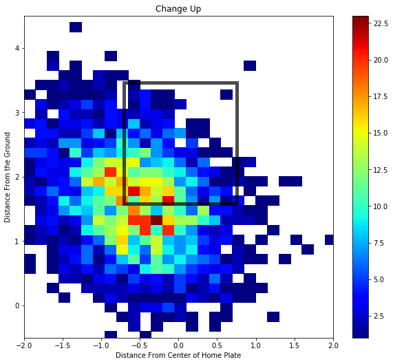

```python
left, width = 0.1, 0.65
bottom, height = 0.1, 0.65
bottom_h = left_h = left + width + 0.02

rect_scatter = [left, bottom, width, height]
#rect_histx = [left, bottom_h, width, 0.2]
#rect_histy = [left_h, bottom, 0.2, height]

plt.figure(1, figsize=(12, 10))

# start with a rectangular Figure

axScatter = plt.axes(rect_scatter)
#axHistx = plt.axes(rect_histx)
#axHisty = plt.axes(rect_histy)
bins_x = np.arange(-2, 0.1+2,0.15)
bins_y = np.arange(-1, 0.1+6, 0.15)
plt.hist2d(data = ch, x = 'px', y = 'pz', bins = [bins_x, bins_y], cmap = 'jet', cmin = 1);
axScatter.set_xlim((-2, 2))
axScatter.set_ylim((-0.5, 4.5))
someX = 0
someY = 3.4632659
axScatter.add_patch(Rectangle((someX - .7083 , someY - 1.8832 ), 1.467, 1.8832, color = 'black',fill=None, alpha=0.7, lw = 5))
plt.colorbar();
plt.title('Change Up');
plt.xlabel('Distance From Center of Home Plate')
plt.ylabel('Distance From the Ground');
```

## Curveball Location Heat Map

> This is interesting to see where Greinke throws his curveball. He throws it a lot in the bottom middle of the strike zone and sometimes below the strike zone.(View from the catcher). His curveball breaks from left to right in a sweeping motion. This makes locating this pitch in the middle of the strike zone and down effective. The pitch can start as a ball and then drop right in.

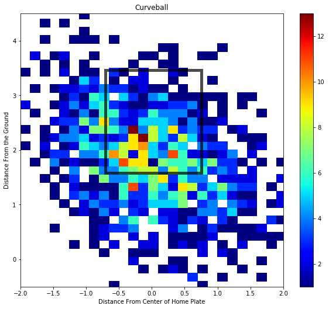

```python
left, width = 0.1, 0.65
bottom, height = 0.1, 0.65
bottom_h = left_h = left + width + 0.02

rect_scatter = [left, bottom, width, height]
#rect_histx = [left, bottom_h, width, 0.2]
#rect_histy = [left_h, bottom, 0.2, height]

plt.figure(1, figsize=(12, 10))

# start with a rectangular Figure


axScatter = plt.axes(rect_scatter)
#axHistx = plt.axes(rect_histx)
#axHisty = plt.axes(rect_histy)
bins_x = np.arange(-2, 0.1+2,0.15)
bins_y = np.arange(-1, 0.1+6, 0.15)
plt.hist2d(data = cu, x = 'px', y = 'pz', bins = [bins_x, bins_y], cmap = 'jet', cmin = 1);
axScatter.set_xlim((-2, 2))
axScatter.set_ylim((-0.5, 4.5))
someX = 0
someY = 3.4632659
axScatter.add_patch(Rectangle((someX - .7083 , someY - 1.8832 ), 1.467, 1.8832, color = 'black',fill=None, alpha=0.7, lw=5))
plt.colorbar();
plt.title('Curveball');
plt.xlabel('Distance From Center of Home Plate')
plt.ylabel('Distance From the Ground');
```

## Slider Location Heat Map

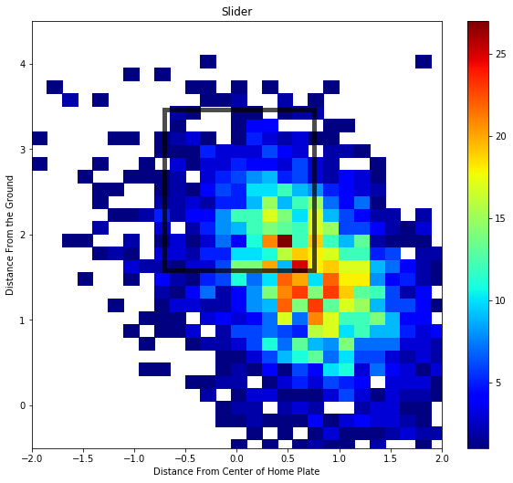

```python
left, width = 0.1, 0.65
bottom, height = 0.1, 0.65
bottom_h = left_h = left + width + 0.02

rect_scatter = [left, bottom, width, height]
#rect_histx = [left, bottom_h, width, 0.2]
#rect_histy = [left_h, bottom, 0.2, height]

plt.figure(1, figsize=(12, 10))

# start with a rectangular Figure

axScatter = plt.axes(rect_scatter)
#axHistx = plt.axes(rect_histx)
#axHisty = plt.axes(rect_histy)
bins_x = np.arange(-2, 0.1+2,0.15)
bins_y = np.arange(-1, 0.1+6, 0.15)
plt.hist2d(data = sl, x = 'px', y = 'pz', bins = [bins_x, bins_y], cmap = 'jet', cmin = 1);
axScatter.set_xlim((-2, 2))
axScatter.set_ylim((-0.5, 4.5))
someX = 0
someY = 3.4632659
axScatter.add_patch(Rectangle((someX - .7083 , someY - 1.8832 ), 1.467, 1.8832, color = 'black',fill=None, alpha=0.7, lw = 5))
plt.colorbar();
plt.title('Slider');
plt.xlabel('Distance From Center of Home Plate')
plt.ylabel('Distance From the Ground');
```

## Nasty Factory by Location

> The nasty factor is how good the pitch is. It uses a number of variables to calculate this. It isn't a real stat, but it is cool to look at. We see that the nastiest pitches (green) are towards the corners of the strike zone (the black rectangle). This is much like some of the sliders and change ups that he throws.

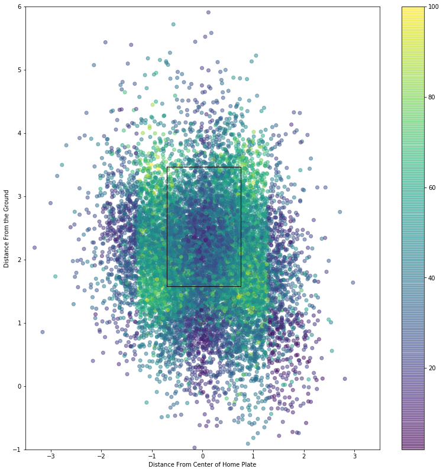

```python
nullfmt = NullFormatter()
left, width = 0.1, 0.65
bottom, height = 0.1, 0.65
bottom_h = left_h = left + width + 0.02

rect_scatter = [left, bottom, width, height]
#rect_histx = [left, bottom_h, width, 0.2]
#rect_histy = [left_h, bottom, 0.2, height]

# start with a rectangular Figure
plt.figure(1, figsize=(16, 16))

axScatter = plt.axes(rect_scatter)
#axHistx = plt.axes(rect_histx)
#axHisty = plt.axes(rect_histy)

# no labels
#axHistx.xaxis.set_major_formatter(nullfmt)
#axHisty.yaxis.set_major_formatter(nullfmt)

# the scatter plot:
sc = plt.scatter(df.px, df.pz, c = df.nasty, alpha = 0.5)

# now determine nice limits by hand:
#binwidth = 0.25
#xymax = max(np.max(np.abs(df.px)), np.max(np.abs(df.pz)))
#lim = (int(xymax/binwidth) + 1) * binwidth

axScatter.set_xlim((-3.5, 3.5))
axScatter.set_ylim((-1, 6))

#bins = np.arange(-lim, lim + binwidth, binwidth)
#axHistx.hist(df.px, bins=bins)
#axHisty.hist(df.pz, bins=bins, orientation='horizontal')

#axHistx.set_xlim(axScatter.get_xlim())
#axHisty.set_ylim(axScatter.get_ylim())

someX = 0
someY = 3.4632659
axScatter.add_patch(Rectangle((someX - .7083 , someY - 1.8832 ), 1.467, 1.8832, fill=None, alpha=1))
plt.colorbar(sc)

plt.xlabel('Distance From Center of Home Plate')
plt.ylabel('Distance From the Ground');
plt.show()
```

## Pitch Location for Nasty Factor > 70

> Previously, we looked at all of the pitches with a color map using the nasty factor value. Let's now see the location of pitches with a nasty factor greater than 70. It is interesting to see they are all on the corners and mainly lower in the zone.

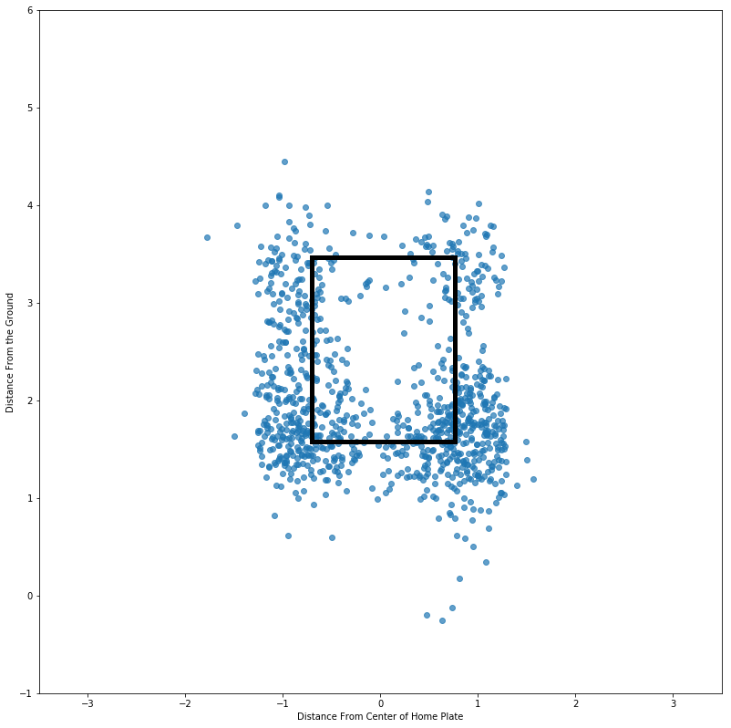

```python
df_nasty= df.query('nasty >= 70')
nullfmt = NullFormatter()
left, width = 0.1, 0.65
bottom, height = 0.1, 0.65
bottom_h = left_h = left + width + 0.02

rect_scatter = [left, bottom, width, height]
#rect_histx = [left, bottom_h, width, 0.2]
#rect_histy = [left_h, bottom, 0.2, height]

# start with a rectangular Figure
plt.figure(1, figsize=(16, 16))

axScatter = plt.axes(rect_scatter)
#axHistx = plt.axes(rect_histx)
#axHisty = plt.axes(rect_histy)

# no labels
#axHistx.xaxis.set_major_formatter(nullfmt)
#axHisty.yaxis.set_major_formatter(nullfmt)

# the scatter plot:
sc = plt.scatter(df_nasty.px, df_nasty.pz, alpha = 0.7)

# now determine nice limits by hand:
#binwidth = 0.25
#xymax = max(np.max(np.abs(df.px)), np.max(np.abs(df.pz)))
#lim = (int(xymax/binwidth) + 1) * binwidth

axScatter.set_xlim((-3.5, 3.5))
axScatter.set_ylim((-1, 6))

#bins = np.arange(-lim, lim + binwidth, binwidth)
#axHistx.hist(df.px, bins=bins)
#axHisty.hist(df.pz, bins=bins, orientation='horizontal')

#axHistx.set_xlim(axScatter.get_xlim())
#axHisty.set_ylim(axScatter.get_ylim())

someX = 0
someY = 3.4632659
axScatter.add_patch(Rectangle((someX - .7083 , someY - 1.8832 ), 1.467, 1.8832, fill=None, alpha=1, lw = 5))
#plt.colorbar(sc)

plt.xlabel('Distance From Center of Home Plate')
plt.ylabel('Distance From the Ground');
plt.show()
```

## Pitch Speed and Location for Nasty Factor > 70

> Previously, we looked at the location of pitches with a nasty factor greater than 70. It is interesting to see they are all on the corners and mainly lower in the zone. What are the start speeds for these pitches? It looks like a lot of the pitches on the corners/out of the zone are higher speeds than those that are inside.

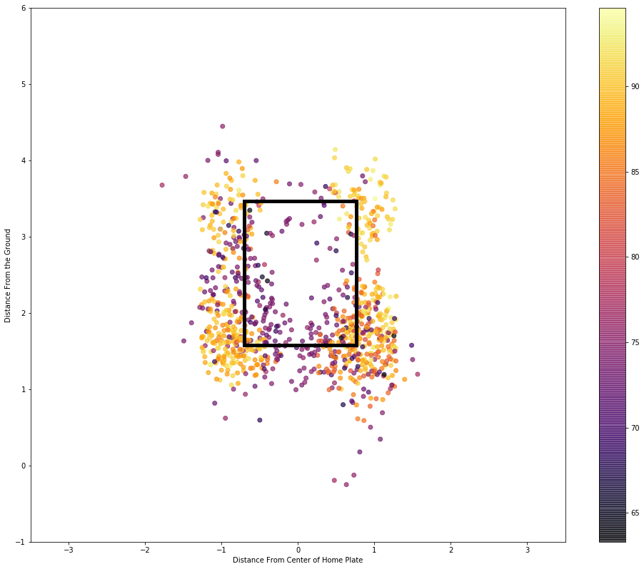

```python
nullfmt = NullFormatter()
left, width = 0.1, 0.65
bottom, height = 0.1, 0.65
bottom_h = left_h = left + width + 0.02

rect_scatter = [left, bottom, width, height]
#rect_histx = [left, bottom_h, width, 0.2]
#rect_histy = [left_h, bottom, 0.2, height]

# start with a rectangular Figure
plt.figure(1, figsize=(20,16 ))

axScatter = plt.axes(rect_scatter)
#axHistx = plt.axes(rect_histx)
#axHisty = plt.axes(rect_histy)

# no labels
#axHistx.xaxis.set_major_formatter(nullfmt)
#axHisty.yaxis.set_major_formatter(nullfmt)

# the scatter plot:
sc = plt.scatter(df_nasty.px, df_nasty.pz,  c = df_nasty.start_speed, cmap = 'inferno' , alpha = 0.7)

# now determine nice limits by hand:
#binwidth = 0.25
#xymax = max(np.max(np.abs(df.px)), np.max(np.abs(df.pz)))
#lim = (int(xymax/binwidth) + 1) * binwidth

axScatter.set_xlim((-3.5, 3.5))
axScatter.set_ylim((-1, 6))

#bins = np.arange(-lim, lim + binwidth, binwidth)
#axHistx.hist(df.px, bins=bins)
#axHisty.hist(df.pz, bins=bins, orientation='horizontal')

#axHistx.set_xlim(axScatter.get_xlim())
#axHisty.set_ylim(axScatter.get_ylim())

someX = 0
someY = 3.4632659
axScatter.add_patch(Rectangle((someX - .7083 , someY - 1.8832 ), 1.467, 1.8832, fill=None, alpha=1, lw = 5))
plt.colorbar(sc)

plt.xlabel('Distance From Center of Home Plate')
plt.ylabel('Distance From the Ground');
plt.show()
```

## Pitch Type and Location for Nasty Factor > 70

> Previously, we looked at the location of pitches, and their velocities, with a nasty factor greater than 70. It is interesting to see they are all on the corners and mainly lower in the zone. We can also see that his curveball and is about the only pitch in the zone. This tells us his curve is really good. He doesn't have to be so borderline and accurate with it and still get good results.

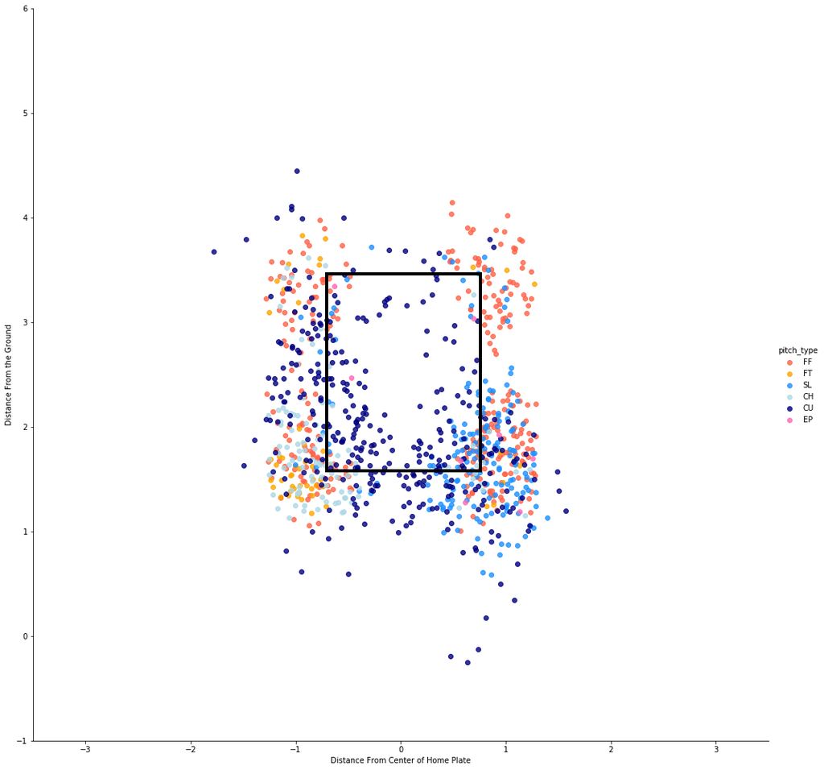

```python
color = ['tomato', 'orange','dodgerblue','lightblue','navy', 'hotpink']
g = sb.FacetGrid(data = df_nasty, hue = 'pitch_type', height = 14, palette = color)
g = g.map(sb.regplot, 'px','pz', fit_reg = False)

someX = 0
someY = 3.4632659
g.axes[0, 0].add_patch(Rectangle((someX - .7083 , someY - 1.8832 ), 1.467, 1.8832, fill=None, color = 'black', alpha=1, lw = 4))
g.add_legend()
axes = g.axes
axes[0,0].set_xlim(-3.5,3.5)
axes[0,0].set_ylim(-1,6)
plt.xlabel('Distance From Center of Home Plate')
plt.ylabel('Distance From the Ground');
plt.show()
```